# cRacle_BETA

### And find the optima for these joint likelihood functions.

```r
optim = get_optim(and)

print(optim$origk) #As implemented in Harbert and Nixon, 2015
```

```
##   bio1.origkde bio2.origkde bio3.origkde bio4.origkde bio5.origkde bio6.origkde
## 1     53.85142     86.45552     27.94624     9614.010      239.347    -165.0469
## 2     56.46725     87.41740     28.16129     9760.065      242.393    -160.6129
##   bio7.origkde bio8.origkde bio9.origkde bio10.origkde bio11.origkde
## 1     396.3441    -12.42229    -70.99707      163.7849     -92.78006
## 2     401.1828     -7.40176    -66.40567      165.6735     -87.69501
##   bio12.origkde bio13.origkde bio14.origkde bio15.origkde bio16.origkde
## 1      1457.199      142.7478      104.8866      13.01075      384.3089
## 2      1467.716      144.1437      105.5982      13.78495      388.3460
##   bio17.origkde bio18.origkde bio19.origkde
## 1      323.5865      381.7097      349.7097
## 2      326.0323      383.7830      355.0323
```

```r
print(optim$conintkde) #with 95% confidence intervals on the likelihood distribution.
```

```
##   bio1.cikde bio2.cikde bio3.cikde bio4.cikde bio5.cikde bio6.cikde bio7.cikde
## 1   40.77224   83.48974   27.06452   9127.157   228.7664  -178.0323   370.8065
## 2   63.66080   91.98631   28.97849  10205.188   254.4164  -118.4897   412.2043
##   bio8.cikde bio9.cikde bio10.cikde bio11.cikde bio12.cikde bio13.cikde
## 1  -27.48387  -83.93646    157.3324  -105.64223    1366.378    137.2805
## 2   11.73900  -40.10948    174.8016   -48.80938    1491.616    148.4477
##   bio14.cikde bio15.cikde bio16.cikde bio17.cikde bio18.cikde bio19.cikde
## 1    100.4389    11.46237    373.0626    300.4878    370.7507    327.3548
## 2    107.5552    18.55914    410.8387    332.5543    390.5953    369.9355
```

### And visualize (for Mean Annual Temperature):

multiplot() plots the object created by dens_obj(). addplot() plots a single element of dens_obj() (e.g. densall[[1]]) or a similar object created by the and_fun() function.

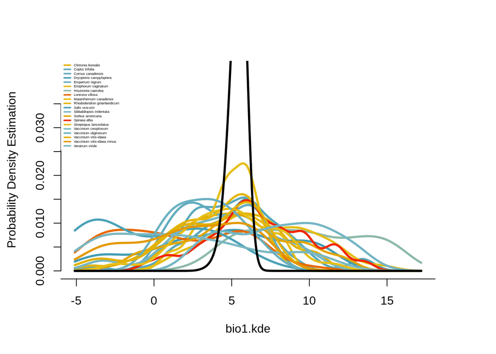

```r
n = 1
multiplot(densall, names(clim)[[n]], l.cex=0.3)
addplot(and, names(clim)[[n]], col = 'black')

abline(v = median(optim$origk[, n]), col = 'green') #Midpoint will be very close to the optimum. Original method of Harbert and Nixon, 2015 returned a top 1% range to introduce some slop
```

# cRacle performance

To see how well we have done with cRacle let's have compare to the WorldClim model output as well as a summary of data from nearby weather stations from NOAA.

### Get NOAA data

```r
require(rnoaa);
```

```r
require(ggplot2);
station_data <- ghcnd_stations() # Takes a while to run (minutes)
```

[output not shown]

[output not shown]

[output not shown]

[output not shown]

```r
lat_lon_df <- data.frame(id = 'locality',
                         latitude = c(site.coord[1]),
                         longitude = c(site.coord[2]))
nearby_stations <-  meteo_nearby_stations(lat_lon_df = lat_lon_df,
                                          #var = c('TMIN', 'TMAX', 'TAVG', 'PRCP'),
                                          station_data = station_data,
                                          radius = 10)
monitors <- nearby_stations$locality$id

all_monitors_clean <- meteo_pull_monitors(monitors) #get GHCN Data for each nearby station.
```

[output not shown]

[output not shown]

```
## file min/max dates: 1948-01-01 / 2020-10-31
```

[output not shown]

[output not shown]

```
## file min/max dates: 2016-12-01 / 2020-04-30
```

[output not shown]

[output not shown]

```
## file min/max dates: 1947-03-01 / 1950-09-30
```

[output not shown]

[output not shown]

```
## file min/max dates: 2016-12-01 / 2020-04-30
```

[output not shown]

[output not shown]

```
## file min/max dates: 1930-01-01 / 2020-10-31
```

[output not shown]

[output not shown]

```
## file min/max dates: 1994-09-01 / 2005-05-31
```

```r
summary(all_monitors_clean);
```

```
##       id                 date                 acmh             acsh
##  Length:65039       Min.   :1930-01-01   Min.   :  0.00   Min.   :  0.00
##  Class :character   1st Qu.:1959-09-19   1st Qu.: 70.00   1st Qu.: 70.00
##  Mode  :character   Median :1982-01-22   Median : 90.00   Median :100.00
##                     Mean   :1980-07-14   Mean   : 79.14   Mean   : 80.29
##                     3rd Qu.:2001-02-16   3rd Qu.:100.00   3rd Qu.:100.00
##                     Max.   :2020-10-31   Max.   :113.00   Max.   :113.00
##                                          NA's   :52543    NA's   :50237
##       awnd            fmtm            pgtm            prcp
##  Min.   : 10.0   Min.   :  50    Min.   :    0   Min.   :   0.00
##  1st Qu.:100.0   1st Qu.: 495    1st Qu.:  354   1st Qu.:   0.00
##  Median :154.0   Median : 940    Median : 1236   Median :   3.00
##  Mean   :160.2   Mean   : 940    Mean   : 1207   Mean   :  52.51
##  3rd Qu.:213.0   3rd Qu.:1385    3rd Qu.: 2040   3rd Qu.:  53.00
##  Max.   :492.0   Max.   :1830    Max.   :32767   Max.   :2748.00
##  NA's   :55442   NA's   :65037   NA's   :47157   NA's   :4947
##       psun            snow              snwd             tavg
##  Min.   :  0     Min.   :   0.00   Min.   :   0.0   Min.   :-322.00
##  1st Qu.:  0     1st Qu.:   0.00   1st Qu.:   0.0   1st Qu.: -39.00
##  Median : 17     Median :   0.00   Median :   0.0   Median :  39.00
##  Mean   : 33     Mean   :  15.41   Mean   : 207.7   Mean   :  34.04
##  3rd Qu.: 64     3rd Qu.:   0.00   3rd Qu.: 279.0   3rd Qu.: 115.00
##  Max.   :100     Max.   :1252.00   Max.   :4166.0   Max.   : 285.00
##  NA's   :52817   NA's   :5946      NA's   :7815     NA's   :60418
##       tmax              tmin              tobs              tsun
##  Min.   :-333.00   Min.   :-433.00   Min.   :-322.00   Min.   :  0.0
##  1st Qu.: -22.00   1st Qu.:-111.00   1st Qu.: -50.00   1st Qu.:  0.0
##  Median :  61.00   Median : -22.00   Median :  28.00   Median :120.0
##  Mean   :  63.24   Mean   : -32.27   Mean   :  26.35   Mean   :244.5
##  3rd Qu.: 150.00   3rd Qu.:  56.00   3rd Qu.: 117.00   3rd Qu.:469.0
##  Max.   : 344.00   Max.   : 283.00   Max.   : 272.00   Max.   :944.0
##  NA's   :717       NA's   :742       NA's   :30266     NA's   :44806
##       wdf2            wdf5            wdfg            wdfi
##  Min.   :90      Min.   :  0     Min.   :  0.0   Min.   : 45
##  1st Qu.:90      1st Qu.:250     1st Qu.:270.0   1st Qu.:270
##  Median :90      Median :270     Median :270.0   Median :270
##  Mean   :90      Mean   :259     Mean   :260.8   Mean   :262
##  3rd Qu.:90      3rd Qu.:315     3rd Qu.:315.0   3rd Qu.:315
##  Max.   :90      Max.   :360     Max.   :900.0   Max.   :360
##  NA's   :65037   NA's   :58160   NA's   :49504   NA's   :61147
```

[output cut: 41 more lines]

```
##  Min.   :1       Min.   :1       Min.   :1       Min.   :1
##  1st Qu.:1       1st Qu.:1       1st Qu.:1       1st Qu.:1
##  Median :1       Median :1       Median :1       Median :1
##  Mean   :1       Mean   :1       Mean   :1       Mean   :1
##  3rd Qu.:1       3rd Qu.:1       3rd Qu.:1       3rd Qu.:1
##  Max.   :1       Max.   :1       Max.   :1       Max.   :1
##  NA's   :57625   NA's   :64439   NA's   :55913   NA's   :62838
##       dapr            mdpr            dasf            mdsf
##  Min.   :2.0     Min.   :  0.0   Min.   :2       Min.   :25
##  1st Qu.:2.0     1st Qu.: 13.0   1st Qu.:2       1st Qu.:25
##  Median :2.0     Median : 51.0   Median :2       Median :25
##  Mean   :2.3     Mean   :104.6   Mean   :2       Mean   :25
##  3rd Qu.:2.0     3rd Qu.:171.5   3rd Qu.:2       3rd Qu.:25
##  Max.   :5.0     Max.   :500.0   Max.   :2       Max.   :25
##  NA's   :65016   NA's   :65012   NA's   :65037   NA's   :65037
```

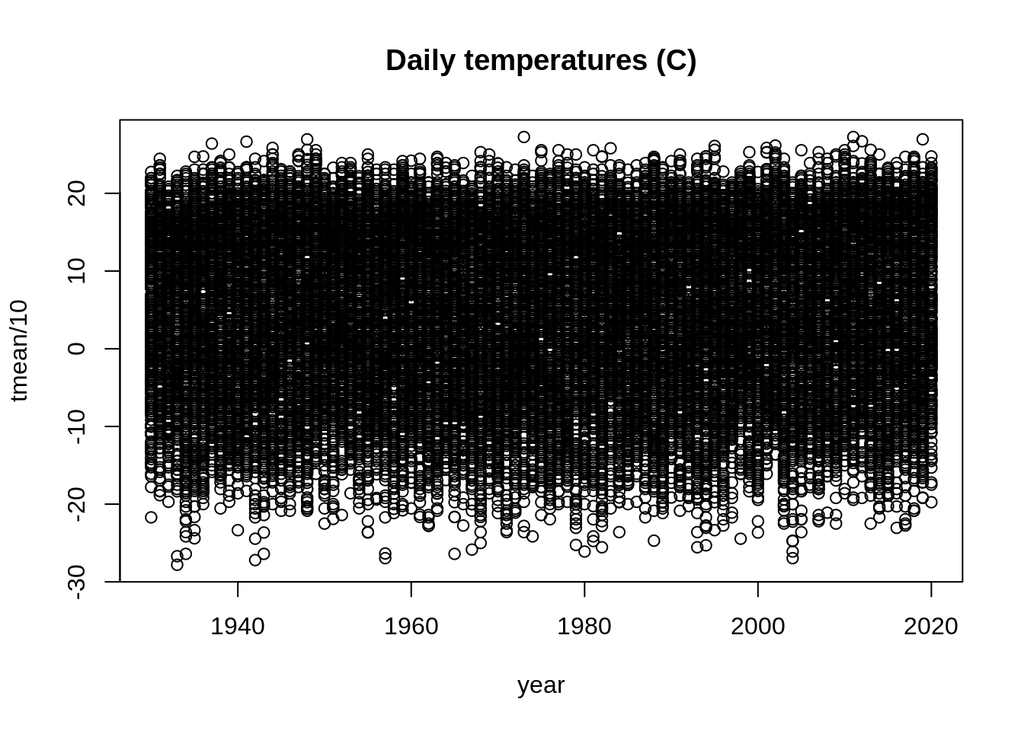

```r
#plot e.g.,
#plot(all_monitors_clean$date, (all_monitors_clean$tmax))

all_monitors_clean = all_monitors_clean[order(all_monitors_clean$date),]
coverage=meteo_coverage(all_monitors_clean)

#autoplot(coverage)
cbase = coverage
coverage = coverage$summary

best_cover = coverage[which(coverage$total_obs == max(coverage$total_obs)),]$id;

monitors_clean = subset(all_monitors_clean, all_monitors_clean$id == best_cover)
dates = monitors_clean$date
datestr = strsplit(as.character(dates), '-')
year = list();
for(i in 1:length(datestr)){
  year[[i]] = datestr[[i]][1];
}
year = unlist(year)
tmean = (monitors_clean$tmax + monitors_clean$tmin)/2

plot(year, tmean/10, main="Daily temperatures (C)")
```

```r
#summarize mean temperature profile
year.tmean = cbind(as.numeric(year), tmean/10)
m = vector(); z = 1;
for(i in min(year.tmean[,1]):(max(year.tmean[,1]))){
  m[z] = mean(as.numeric(year.tmean[which(year.tmean[,1] == i), 2]),
              na.rm=TRUE)
  z = z+1;
}

ghcn.mat = mean(m, na.rm=TRUE) #Mean Annual Temperature
```

### Get WorldClim data for locality

```r
ex = extract(clim, cbind(site.coord[2], site.coord[1])) #extract Worldclim for site
site.ex = cbind(loc.name, site.coord[2], site.coord[1], ex)
colnames(site.ex) = c('locality', 'lon', 'lat', names(clim))
```

### Plot comparison

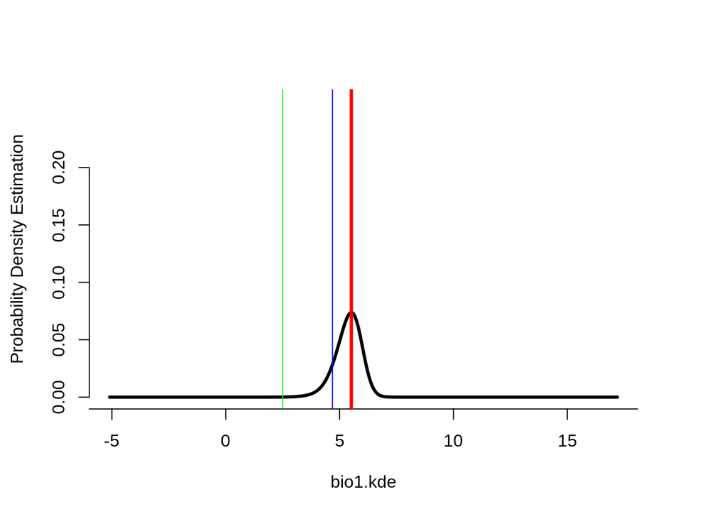

```r
densplot(and, names(clim[[1]]), col = 'black')
abline(v=median(optim$origk[,1])/10, col='red', lwd=3)
abline(v=ghcn.mat, col='blue')
abline(v=as.numeric(site.ex[,names(clim[[1]])])/10, col = 'green')
```

### Recap

The demonstration code above can be found at the cRacle github page: https://github.com/rsh249/cRacle/scripts/cRacle_beta.Rmd